# Tugas Praktikum 3 - MPDW

Sofia Lorena

2025-09-13

# 1. Pemilihan Peubah X dan Y

## A. Berdasarkan Jurnal

Berdasarkan jurnal *“Analysis of the level of CO parameter air pollution on the road of Makassar City”*, Saleh, R., Susilawaty, A., & Ibrahim, I. (2023), karbon monoksida (CO) terbukti memiliki hubungan yang sangat signifikan dan positif dengan tingkat pencemaran udara (ISPU) di Jalan AP Pettarani, Makassar. Nilai korelasi Pearson mencapai lebih dari 0,98 dengan p-value 0,000, menunjukkan bahwa peningkatan konsentrasi CO langsung berkontribusi terhadap penurunan kualitas udara. CO terutama berasal dari emisi kendaraan bermotor, yang menjadi sumber utama polusi udara perkotaan. Konsentrasi CO tertinggi ditemukan pada lokasi dan waktu dengan kepadatan lalu lintas tinggi, seperti pada sore hari di persimpangan jalan. Selain berdampak buruk pada kesehatan manusia, CO juga menjadi indikator yang efektif untuk menilai tingkat polusi udara akibat aktivitas transportasi. Oleh karena itu, CO merupakan parameter yang relevan dan kuat untuk dijadikan variabel dalam evaluasi kualitas udara.

## B. Eksplorasi

```r
# Paket dasar
library(tidyverse)
library(GGally)
# 1. Import data
df <- read.csv("D:\\Kuliah\\SEM 5\\MPDW\\4\\Praktikum\\NewDelhi_Air_quality.csv", stringsAsFactors = FALSE)

names(df)
```

```
##  [1] "X"               "AQI"             "CO"              "datetime"
##  [5] "no2"             "o3"              "pm10"            "pm25"
##  [9] "so2"             "timestamp_local" "timestamp_utc"   "ts"
```

```r
# 2. Seleksi variabel penting
df2 <- df %>%
  select(CO, AQI) %>%
  rename(y = CO, x = AQI) %>%
  drop_na()

# 3. Statistik deskriptif
summary(df2)
```

```
##        y               x
##  Min.   :191.9   Min.   :19.00
##  1st Qu.:197.4   1st Qu.:25.00
##  Median :200.3   Median :27.00
##  Mean   :200.1   Mean   :26.18
##  3rd Qu.:203.6   3rd Qu.:28.00
##  Max.   :208.6   Max.   :32.00
```

```r
# 4. Korelasi Pearson & Spearman
cor(df2$y, df2$x, method = "pearson")
```

```
## [1] 0.7976332
```

```r
cor(df2$y, df2$x, method = "spearman")
```

```
## [1] 0.7426415
```

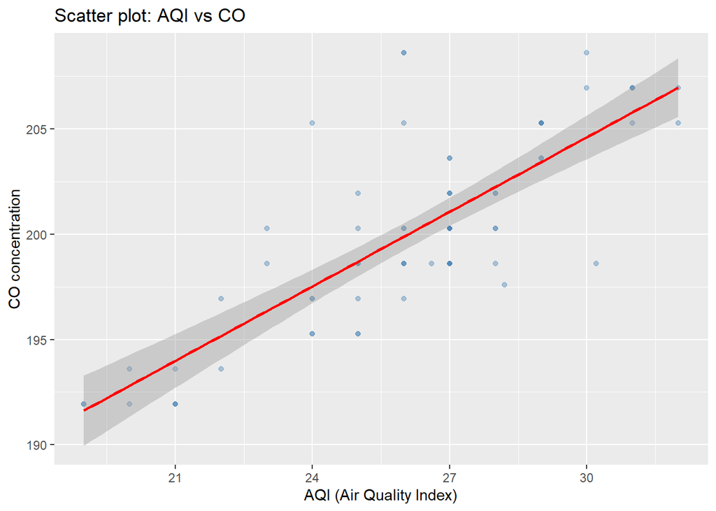

```r
# 5. Scatter plot dengan regresi linear
ggplot(df2, aes(x = x, y = y)) +
  geom_point(alpha = 0.4, color = "steelblue") +
  geom_smooth(method = "lm", se = TRUE, color = "red") +
  labs(title = "Scatter plot: AQI vs CO",
       x = "AQI (Air Quality Index)",
       y = "CO concentration")
```

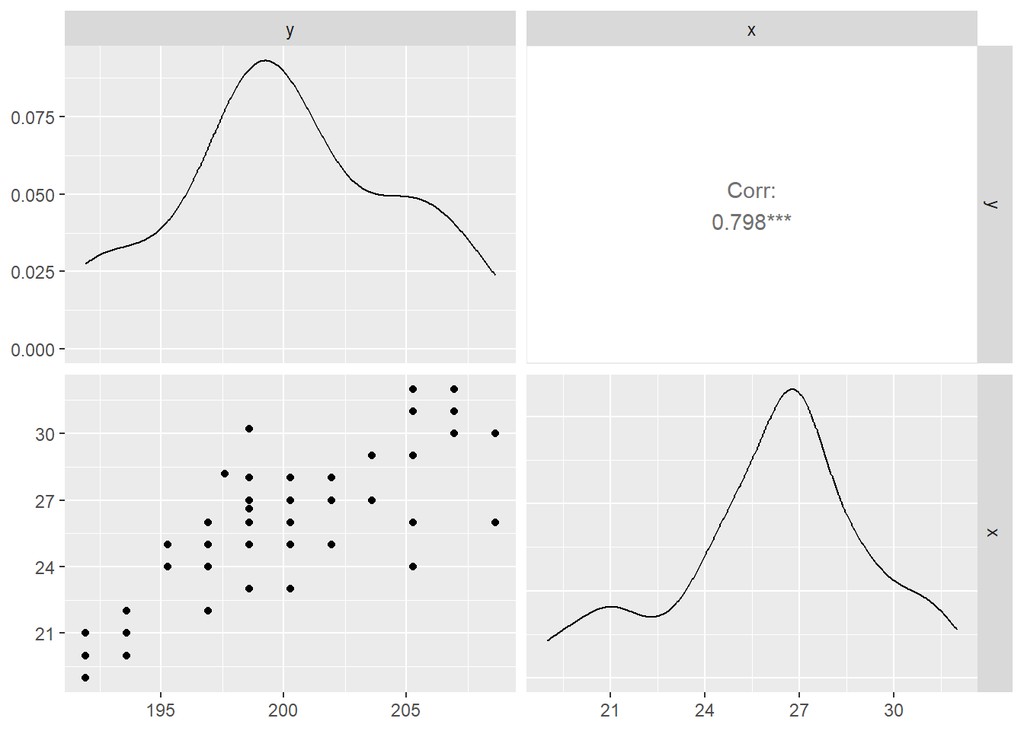

```r
# 6. Pairplot untuk eksplorasi hubungan
ggpairs(df2)
```

**Interpretasi:**

*1. Scatter Plot (AQI vs CO)*

- Arah hubungan: Garis regresi merah menunjukkan slope positif → artinya semakin tinggi AQI, semakin tinggi pula konsentrasi CO.
- Kekuatan hubungan: Titik-titik relatif mengikuti pola garis dengan sebaran yang tidak terlalu jauh, sehingga hubungannya cukup kuat.
- Makna: Kualitas udara yang memburuk (AQI tinggi) erat kaitannya dengan meningkatnya kadar CO di udara.

*2. Pairplot & Korelasi*

- Nilai korelasi Pearson (r = 0.798, p < 0.001): menunjukkan hubungan kuat dan signifikan positif antara AQI dan CO.
- Distribusi variabel: CO terkonsentrasi sekitar 195–205, dengan distribusi agak simetris. AQI terkonsentrasi sekitar 24–28.
- Interpretasi: Variasi CO cukup mampu menjelaskan variasi AQI. Jadi, CO merupakan kandidat peubah yang relevan untuk dianalisis sebagai faktor penentu kualitas udara.

# 2. Eksplorasi Data

```r
# Import library
library(tidyverse)
library(ggplot2)
library(GGally)
library(lmtest)
library(dynlm)
library(tseries)
library(dLagM)
# Load data
data <- read.csv("D:\\Kuliah\\SEM 5\\MPDW\\4\\Praktikum\\NewDelhi_Air_quality.csv")
data
```

```
##     X  AQI       CO      datetime        no2       o3      pm10     pm25
## 1   0 30.2 198.6027 2022-10-21:18 0.04685717 55.78995 10.486722 5.637410
## 2   1 28.2 197.6013 2022-10-21:19 0.04645554 54.93164 10.719325 4.618169
## 3   2 26.6 198.6027 2022-10-21:20 0.04685717 54.64554 11.155578 3.520902
## 4   3 25.0 201.9405 2022-10-21:21 0.04819594 55.07469 11.116206 2.225919
## 5   4 26.0 205.2784 2022-10-21:22 0.04886533 55.78995 10.405250 1.979471
## 6   5 26.0 208.6163 2022-10-21:23 0.05020411 56.50520  9.402518 1.792677
## 7   6 26.0 208.6163 2022-10-22:00 0.05020411 55.78995  8.482822 1.752237
## 8   7 24.0 205.2784 2022-10-22:01 0.05020411 52.92892  7.586667 1.858459
## 9   8 23.0 200.2716 2022-10-22:02 0.04685717 50.06790  7.636587 2.208076
## 10  9 24.0 196.9338 2022-10-22:03 0.04417961 51.49841  8.487648 2.476681
## 11 10 25.0 198.6027 2022-10-22:04 0.04284084 53.64418  9.357371 2.585729
## 12 11 26.0 200.2716 2022-10-22:05 0.04049798 55.78995 10.338728 2.390081
## 13 12 27.0 203.6095 2022-10-22:06 0.04016329 59.36623 10.523314 2.086022
## 14 13 29.0 205.2784 2022-10-22:07 0.03882451 62.22725 10.635970 1.937047
```

[output cut: 131 more lines]

```r
# Cek struktur data
str(data)
```

```
## 'data.frame':    72 obs. of  12 variables:
##  $ X              : int  0 1 2 3 4 5 6 7 8 9 ...
##  $ AQI            : num  30.2 28.2 26.6 25 26 26 26 24 23 24 ...
##  $ CO             : num  199 198 199 202 205 ...
##  $ datetime       : chr  "2022-10-21:18" "2022-10-21:19" "2022-10-21:20" "2022-10-21:21" ...
##  $ no2            : num  0.0469 0.0465 0.0469 0.0482 0.0489 ...
##  $ o3             : num  55.8 54.9 54.6 55.1 55.8 ...
##  $ pm10           : num  10.5 10.7 11.2 11.1 10.4 ...
##  $ pm25           : num  5.64 4.62 3.52 2.23 1.98 ...
##  $ so2            : num  0.387 0.41 0.402 0.376 0.339 ...
##  $ timestamp_local: chr  "2022-10-21T23:00:00" "2022-10-22T00:00:00" "2022-10-22T01:00:00" "2022-10-22T02:00:00" ...
##  $ timestamp_utc  : chr  "2022-10-21T18:00:00" "2022-10-21T19:00:00" "2022-10-21T20:00:00" "2022-10-21T21:00:00" ...
##  $ ts             : int  1666375200 1666378800 1666382400 1666386000 1666389600 1666393200 1666396800 1666400400 1666404000 1666407600 ...
```

```r
summary(data)
```

```
##        X              AQI              CO          datetime
##  Min.   : 0.00   Min.   :19.00   Min.   :191.9   Length:72
##  1st Qu.:17.75   1st Qu.:25.00   1st Qu.:197.4   Class :character
##  Median :35.50   Median :27.00   Median :200.3   Mode  :character
##  Mean   :35.50   Mean   :26.18   Mean   :200.1
##  3rd Qu.:53.25   3rd Qu.:28.00   3rd Qu.:203.6
##  Max.   :71.00   Max.   :32.00   Max.   :208.6
##       no2                o3             pm10             pm25
##  Min.   :0.01556   Min.   :41.48   Min.   : 6.687   Min.   :1.633
##  1st Qu.:0.03799   1st Qu.:53.64   1st Qu.: 7.865   1st Qu.:1.829
##  Median :0.04552   Median :57.22   Median : 8.914   Median :2.202
##  Mean   :0.04200   Mean   :56.57   Mean   : 9.115   Mean   :2.295
##  3rd Qu.:0.05020   3rd Qu.:60.08   3rd Qu.:10.275   3rd Qu.:2.522
##  Max.   :0.06091   Max.   :68.66   Max.   :12.846   Max.   :5.637
##       so2         timestamp_local    timestamp_utc            ts
##  Min.   :0.2831   Length:72          Length:72          Min.   :1.666e+09
##  1st Qu.:0.3204   Class :character   Class :character   1st Qu.:1.666e+09
##  Median :0.3725   Mode  :character   Mode  :character   Median :1.667e+09
##  Mean   :0.3634                                         Mean   :1.667e+09
##  3rd Qu.:0.3958                                         3rd Qu.:1.667e+09
##  Max.   :0.4545                                         Max.   :1.667e+09
```

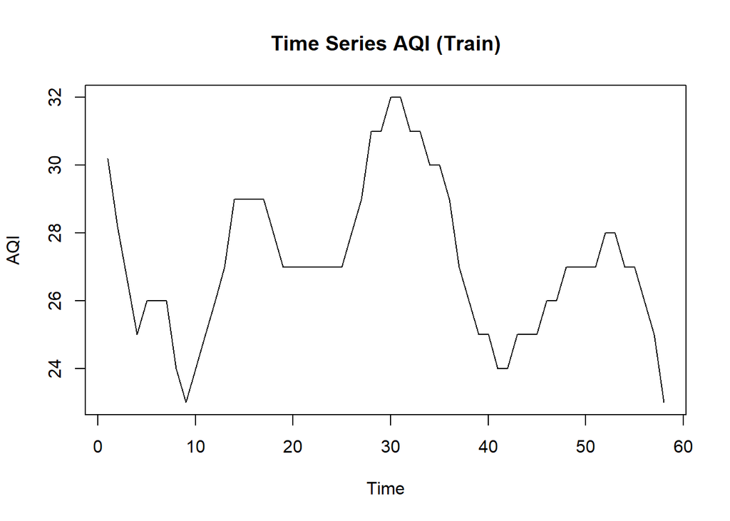

```r
# Ambil variabel
df <- data %>%
  select(AQI, CO) %>%
  drop_na()

# Train-test split (80-20)
n <- nrow(df)
train_size <- round(0.8 * n)
train <- df[1:train_size, ]
test  <- df[(train_size+1):n, ]

# Plot time series
plot.ts(train$AQI, main="Time Series AQI (Train)", ylab="AQI")
```

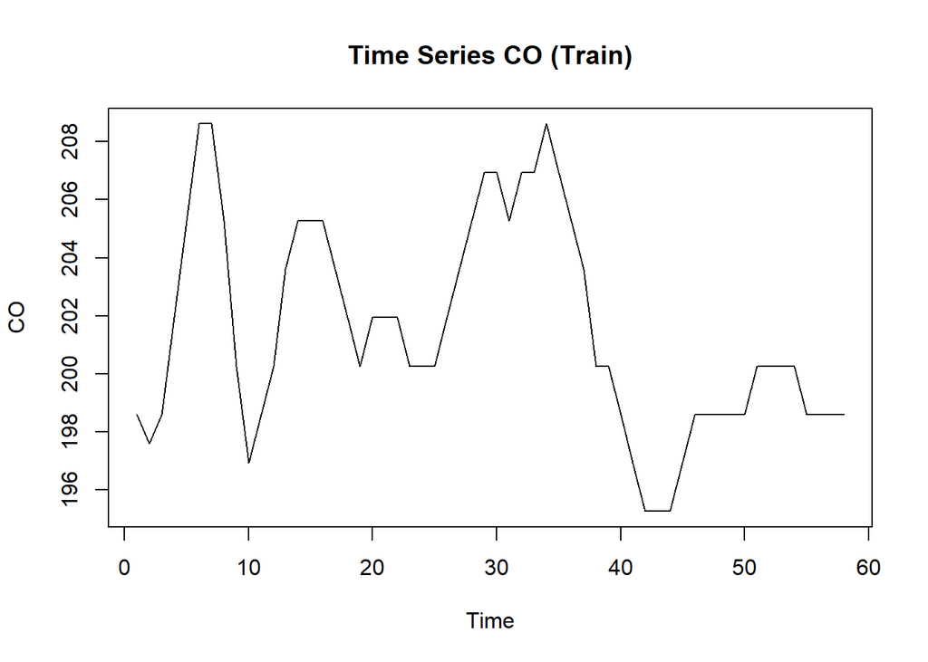

```r
plot.ts(train$CO, main="Time Series CO (Train)", ylab="CO")
```

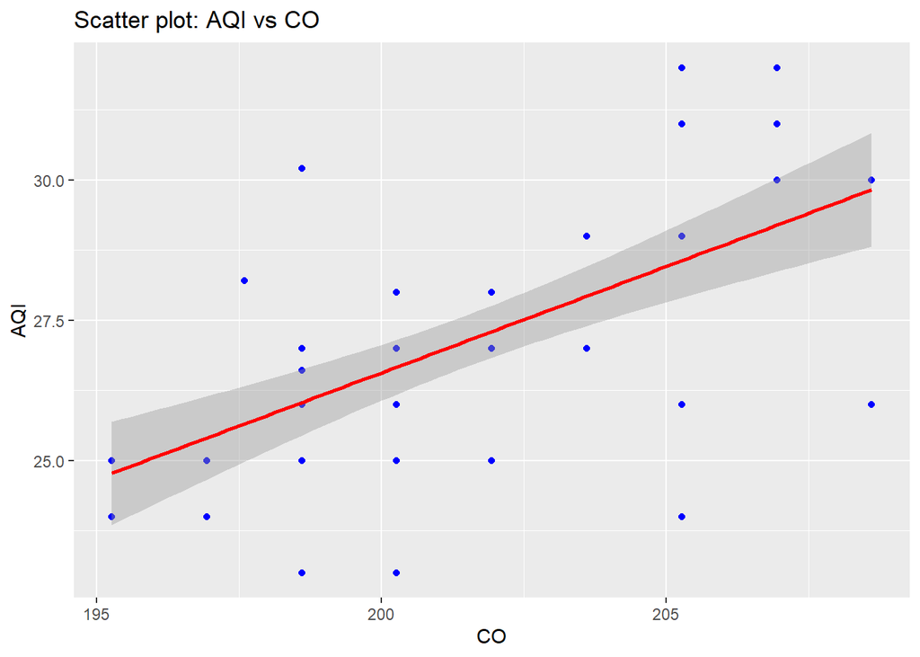

```r
# Scatterplot
ggplot(train, aes(x=CO, y=AQI)) +
  geom_point(color="blue") +
  geom_smooth(method="lm", se=TRUE, color="red") +
  ggtitle("Scatter plot: AQI vs CO")
```

```r
# Korelasi
cor(train$AQI, train$CO, use="complete.obs")
```

```
## [1] 0.6231493
```

1. *Time Series AQI (Train)*
- Grafik menunjukkan pergerakan Air Quality Index (AQI) terhadap waktu.
- Pola AQI berfluktuasi, dengan nilai terendah sekitar 23 dan tertinggi sekitar 32.
- Tidak tampak tren naik/turun yang jelas dalam jangka panjang, tetapi ada indikasi pola siklis (naik–turun) yang berulang.
- Hal ini menunjukkan bahwa kualitas udara (AQI) cenderung dipengaruhi oleh faktor musiman atau fluktuasi jangka pendek.
2. *Time Series CO (Train)*
- Grafik menunjukkan pergerakan kadar CO (karbon monoksida) terhadap waktu.
- Nilai CO berfluktuasi antara 195–209.
- Sama seperti AQI, CO juga tampak memiliki pola siklis (fluktuasi naik-turun) tanpa tren jangka panjang yang jelas.
- Puncak CO terjadi di sekitar awal dan pertengahan periode, sementara nilai rendah terjadi di pertengahan akhir periode.
3. *Scatter Plot: AQI vs CO*
- Scatter plot menunjukkan hubungan antara CO (sumbu X) dan AQI (sumbu Y).
- Titik-titik data menyebar, tetapi garis regresi (garis merah) menunjukkan hubungan positif: semakin tinggi kadar CO, semakin tinggi pula AQI.
- Hal ini berarti CO adalah salah satu faktor yang berkontribusi terhadap kenaikan indeks kualitas udara (dalam konteks ini, AQI lebih tinggi = kualitas udara memburuk).
- Area bayangan abu-abu di sekitar garis regresi adalah confidence interval, yang mengindikasikan ketidakpastian estimasi hubungan.

**Kesimpulan Umum**

1. Baik AQI maupun CO menunjukkan pola fluktuasi siklis, bukan tren jangka panjang.
2. Terdapat korelasi positif antara CO dan AQI: semakin tinggi CO, semakin tinggi nilai AQI.
3. Dengan demikian, kadar CO dapat dijadikan salah satu variabel prediktor dalam pemodelan AQI, misalnya melalui regresi atau time series multivariat (seperti VAR atau ARIMAX).

# 3. Cek Asumsi

```r
model_awal <- lm(AQI ~ CO, data = data)
summary(model_awal)
```

```
##
## Call:
## lm(formula = AQI ~ CO, data = data)
##
## Residuals:
##     Min      1Q  Median      3Q     Max
## -4.9772 -0.7730  0.2741  1.1223  4.8249
##
## Coefficients:
##              Estimate Std. Error t value Pr(>|t|)
## (Intercept) -81.78678    9.76044  -8.379 3.65e-12 ***
## CO            0.53958    0.04877  11.065  < 2e-16 ***
## ---
## Signif. codes:  0 '***' 0.001 '**' 0.01 '*' 0.05 '.' 0.1 ' ' 1
##
## Residual standard error: 1.856 on 70 degrees of freedom
## Multiple R-squared:  0.6362, Adjusted R-squared:  0.631
## F-statistic: 122.4 on 1 and 70 DF,  p-value: < 2.2e-16
```

## A. Autokorelasi Residual

```r
dwtest(model_awal)
```

```
##
##  Durbin-Watson test
##
## data:  model_awal
## DW = 0.30368, p-value < 2.2e-16
## alternative hypothesis: true autocorrelation is greater than 0
```

Berdasarkan hasil Durbin-Watson test didapatkan p-value < 0.05, maka Tolak H0. Hal ini menandakan ada autokorelasi positif yang signifikan pada residual model regresi.

## B. Normalitas Residual

```r
shapiro.test(residuals(model_awal))
```

```
##
##  Shapiro-Wilk normality test
##
## data:  residuals(model_awal)
## W = 0.95671, p-value = 0.01446
```

Berdasalkan hasil Shapiro-Wilk normality test, didapatkan p-value < 0.05, maka Tolak H0 sehingga dapat disimpulkan bahwa residual tidak berdistribusi normal.

## C. Homoskedastisitas

```r
bptest(model_awal)
```

```
##
##  studentized Breusch-Pagan test
##
## data:  model_awal
## BP = 2.4618, df = 1, p-value = 0.1166
```

Berdasakan hasil studentized Breusch-Pagan test didapatkan p-value > 0.05, maka Terima H0 sehingga dapat disimpulkan bahwa ragam homogen.

# 4. Pembagian Data

## A. Pembagian Data

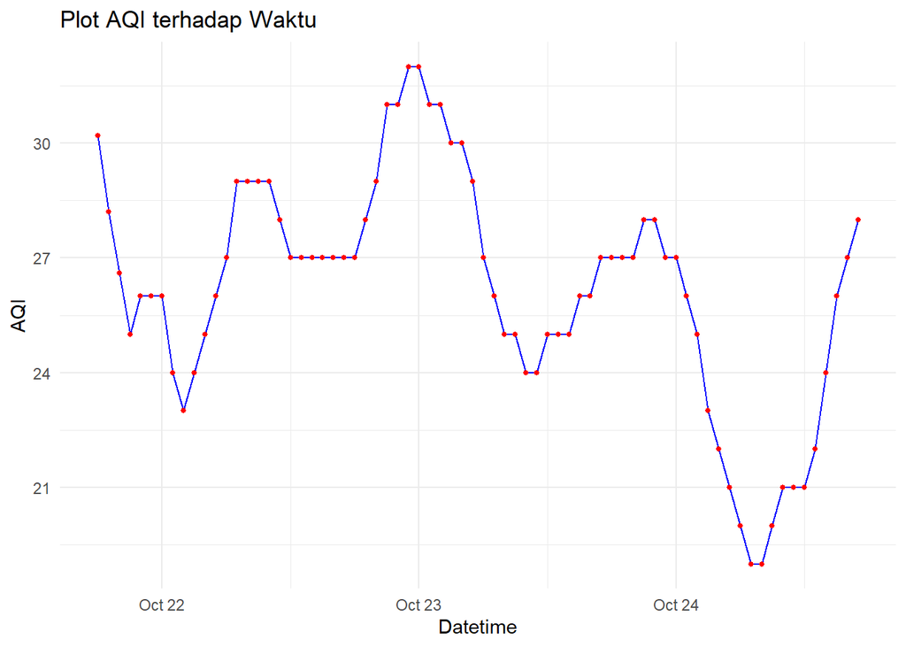

```r
data$datetime <- as.POSIXct(
  data$datetime,
  format = "%Y-%m-%d:%H",
  tz = "UTC"
)

ggplot(data, aes(x = datetime, y = AQI)) +
  geom_line(color = "blue") +
  geom_point(color = "red", size = 1) +
  labs(title = "Plot AQI terhadap Waktu",
       x = "Datetime",
       y = "AQI") +
  theme_minimal()
```

```r
df <- data %>%
  select(AQI, CO) %>%
  drop_na()

n <- nrow(df)
train_size <- round(0.8 * n)

train <- df[1:train_size, ]   # data training (80%)
test  <- df[(train_size+1):n, ]  # data testing (20%)

dim(train)
```

```
## [1] 58  2
```

```r
dim(test)
```

```
## [1] 14  2
```

```r
head(train)
```

```
##    AQI       CO
## 1 30.2 198.6027
## 2 28.2 197.6013
## 3 26.6 198.6027
## 4 25.0 201.9405
## 5 26.0 205.2784
## 6 26.0 208.6163
```

```r
head(test)
```

```
##    AQI       CO
## 59  22 196.9338
## 60  21 193.5959
## 61  20 193.5959
## 62  19 191.9270
## 63  19 191.9270
## 64  20 191.9270
```

# 5. Model

## A. Model Koyck

```r
#MODEL KOYCK
model.koyck <- koyckDlm(x = train$CO, y = train$AQI)
summary(model.koyck)
```

```
##
## Call:
## "Y ~ (Intercept) + Y.1 + X.t"
##
## Residuals:
##     Min      1Q  Median      3Q     Max
## -2.0594 -0.7171  0.1118  0.5371  2.2726
##
## Coefficients:
##             Estimate Std. Error t value Pr(>|t|)
## (Intercept) 1.650115   9.911979   0.166    0.868
## Y.1         0.911852   0.085460  10.670 6.55e-15 ***
## X.t         0.003086   0.056776   0.054    0.957
## ---
## Signif. codes:  0 '***' 0.001 '**' 0.01 '*' 0.05 '.' 0.1 ' ' 1
##
## Residual standard error: 0.9633 on 54 degrees of freedom
## Multiple R-Squared: 0.8139,  Adjusted R-squared: 0.807
## Wald test: 117.9 on 2 and 54 DF,  p-value: < 2.2e-16
##
## Diagnostic tests:
## NULL
##
##                             alpha        beta       phi
## Geometric coefficients:  18.71973 0.003086418 0.9118516
```

```r
AIC(model.koyck)
```

```
## [1] 162.4119
```

```r
BIC(model.koyck)
```

```
## [1] 170.5842
```

**Interpretasi Hasil:**

- Dari `summary`, kita dapatkan model:

  $$\hat{Y_t}=1.650115+0.003086X_t+0.911852Y_{t-1}$$

```r
fore.koyck <- forecast(model = model.koyck, x=test$CO, h=14)
fore.koyck
```

```
## $forecasts
##  [1] 23.23052 23.43042 23.61270 23.77376 23.92062 24.05454 24.17665 24.28800
##  [9] 24.38953 24.48726 24.58153 24.67265 24.76088 24.84133
##
## $call
## forecast.koyckDlm(model = model.koyck, x = test$CO, h = 14)
##
## attr(,"class")
## [1] "forecast.koyckDlm" "dLagM"
```

```r
MAPE(model.koyck)
```

```
##                   MAPE
## model.koyck 0.02682805
```

```r
GoF(model.koyck)
```

```
##              n       MAE          MPE       MAPE      sMAPE     MASE       MSE
## model.koyck 57 0.7190607 -0.001210477 0.02682805 0.02673109 1.082457 0.8790658
##                  MRAE    GMRAE
## model.koyck 759597146 9962.503
```

Model Koyck sebesar 0.02682805 < 10%

## B. Regression with Distributed Lag

```r
#penentuan lag optimum
finiteDLMauto(formula = AQI ~ CO,
              data = data.frame(train), q.min = 1, q.max = 10,
              model.type = "dlm", error.type = "AIC", trace = TRUE)
```

```
##    q - k    MASE      AIC      BIC    GMRAE    MBRAE R.Adj.Sq    Ljung-Box
## 10    10 0.90515 136.4032 160.7288 26818.33  0.54874  0.83325 1.081157e-03
## 9      9 0.92035 137.9987 160.7005 20924.03  0.48557  0.83917 1.442401e-03
## 8      8 1.06658 156.8234 177.8556 18837.93  0.05585  0.78656 1.590823e-02
## 7      7 1.33336 180.5029 199.8212 20418.70  0.06402  0.68114 3.046921e-03
## 6      6 1.46633 197.7025 215.2637 17811.92 -3.45588  0.57122 3.703213e-05
## 5      5 1.65291 210.1633 225.9257 21457.68  0.13138  0.47804 1.537231e-07
## 4      4 1.84421 216.5591 230.4820 34360.90  2.18078  0.43568 1.081398e-08
## 3      3 1.93920 220.8850 232.9289 32422.79  0.57923  0.42049 4.434820e-10
## 2      2 1.84853 221.9900 232.1167 25647.88  0.14415  0.42972 1.024816e-09
## 1      1 1.83815 225.7193 233.8915 20586.68  1.86318  0.41390 2.330515e-09
```

Berdasarkan output tersebut, lag optimum didapatkan ketika lag=10. Selanjutnya dilakukan pemodelan untuk lag=10

```r
#model dlm dengan lag optimum
model.dlm <- dlm(x = train$CO,y = train$AQI , q = 10)
summary(model.dlm)
```

```
##
## Call:
## lm(formula = model.formula, data = design)
##
## Residuals:
##      Min       1Q   Median       3Q      Max
## -2.98455 -0.33973  0.08105  0.39374  2.07432
##
## Coefficients:
##              Estimate Std. Error t value Pr(>|t|)
## (Intercept) -58.80864   12.01631  -4.894 2.08e-05 ***
## x.t           0.49080    0.11521   4.260  0.00014 ***
## x.1           0.14926    0.18074   0.826  0.41433
## x.2          -0.12857    0.18077  -0.711  0.48153
## x.3           0.15065    0.18886   0.798  0.43029
## x.4          -0.02252    0.18919  -0.119  0.90590
## x.5          -0.24536    0.19553  -1.255  0.21763
## x.6           0.12244    0.19188   0.638  0.52744
## x.7          -0.04624    0.19028  -0.243  0.80936
## x.8          -0.06643    0.18143  -0.366  0.71642
## x.9          -0.04978    0.17985  -0.277  0.78355
## x.10          0.07431    0.10354   0.718  0.47756
## ---
## Signif. codes:  0 '***' 0.001 '**' 0.01 '*' 0.05 '.' 0.1 ' ' 1
##
## Residual standard error: 0.8824 on 36 degrees of freedom
## Multiple R-squared:  0.8723, Adjusted R-squared:  0.8332
## F-statistic: 22.35 on 11 and 36 DF,  p-value: 7.332e-13
##
## AIC and BIC values for the model:
##        AIC      BIC
## 1 136.4032 160.7288
```

```r
fore.dlm <- forecast(model = model.dlm, x=test$CO, h=14)
fore.dlm
```

```
## $forecasts
##  [1] 25.09217 23.53126 23.16730 22.60309 21.99961 22.78192 23.02112 22.72719
##  [9] 23.40190 24.32145 25.50897 26.22543 27.41356 27.53790
##
## $call
## forecast.dlm(model = model.dlm, x = test$CO, h = 14)
##
## attr(,"class")
## [1] "forecast.dlm" "dLagM"
```

```r
MAPE(model.dlm)
```

```
##                MAPE
## model.dlm 0.0199312
```

```r
GoF(model.dlm)
```

```
##            n       MAE          MPE      MAPE      sMAPE      MASE       MSE
## model.dlm 48 0.5392354 -0.000767306 0.0199312 0.01982282 0.9051451 0.5840251
##                 MRAE    GMRAE
## model.dlm 2543531521 26818.33
```

## C. Model Autoregressive

```r
model.ardl <- ardlDlm(formula = AQI ~ CO,
                         data = train,p = 1 , q = 1)
summary(model.ardl)
```

```
##
## Time series regression with "ts" data:
## Start = 2, End = 58
##
## Call:
## dynlm(formula = as.formula(model.text), data = data)
##
## Residuals:
##     Min      1Q  Median      3Q     Max
## -2.1904 -0.4113  0.1269  0.5521  1.8932
##
## Coefficients:
##             Estimate Std. Error t value Pr(>|t|)
## (Intercept) -6.48410    7.75439  -0.836  0.40681
## CO.t         0.23359    0.07157   3.264  0.00193 **
## CO.1        -0.18235    0.07018  -2.598  0.01210 *
## AQI.1        0.85407    0.07233  11.808  < 2e-16 ***
## ---
## Signif. codes:  0 '***' 0.001 '**' 0.01 '*' 0.05 '.' 0.1 ' ' 1
##
## Residual standard error: 0.8892 on 53 degrees of freedom
## Multiple R-squared:  0.8443, Adjusted R-squared:  0.8355
## F-statistic: 95.82 on 3 and 53 DF,  p-value: < 2.2e-16
```

```r
AIC(model.ardl)
```

```
## [1] 154.2235
```

```r
BIC(model.ardl)
```

```
## [1] 164.4388
```

Hasil di atas menunjukkan bahwa peubah bahwa $x_t$ , $x_{t-1}$ , $y_{t-1}$ hasil uji t menunjukkan nilai-p pada peubah ≤ 0.05 yang artinya memiliki pengaruh signifikan.

$$\hat{Y_t}=-6.48410+0.23359X_t-0.18235X_{t-1}+0.85407y_{t-1}$$

```r
fore.ardl <- forecast(model = model.ardl, x=test$CO, h=14)
fore.ardl
```

```
## $forecasts
##  [1] 22.94613 22.42475 22.58813 22.33781 22.42836 22.50569 22.57174 22.62815
##  [9] 22.67633 23.10733 23.56095 24.03389 24.52333 24.63702
##
## $call
## forecast.ardlDlm(model = model.ardl, x = test$CO, h = 14)
##
## attr(,"class")
## [1] "forecast.ardlDlm" "dLagM"
```

```r
MAPE(model.ardl)
```

```
##                  MAPE
## model.ardl 0.02502489
```

```r
GoF(model.ardl)
```

```
##             n       MAE           MPE       MAPE     sMAPE     MASE     MSE
## model.ardl 57 0.6713456 -0.0009933262 0.02502489 0.0249233 1.010628 0.73518
##                  MRAE    GMRAE
## model.ardl 1451032386 11922.49
```

```r
model.ardl.opt <- ardlBoundOrders(data = data.frame(data), ic = "AIC",
                                  formula = AQI ~ CO )
model.ardl.opt
```

```
## $p
##   CO
## 1 15
##
## $q
## [1] 6
##
## $Stat.table
##           q = 1    q = 2    q = 3    q = 4    q = 5    q = 6    q = 7    q = 8
## p = 1  168.2819 166.2651 161.6607 157.9799 154.9460 151.9007 142.2749 141.7655
## p = 2  164.8473 163.3331 156.4568 151.0675 150.6558 148.6743 140.6526 141.4722
## p = 3  160.5057 160.5057 158.4568 152.1418 151.9442 149.7779 142.4972 143.2945
## p = 4  155.5034 157.0582 157.0582 153.7779 152.8901 150.8933 144.4972 145.2908
## p = 5  146.4334 147.6417 148.8275 148.8275 146.8885 146.7953 144.1138 145.0288
## p = 6  139.0372 140.7460 142.7230 143.5938 143.5938 144.1934 138.5749 137.9094
## p = 7  140.9979 142.8013 142.6491 141.1302 139.4065 139.4065 140.1131 137.9821
## p = 8  138.7038 138.4923 138.9648 135.5878 135.4907 137.0041 137.0041 138.2546
## p = 9  131.1103 131.5073 133.4716 131.8017 133.3762 134.6431 136.6223 136.6223
## p = 10 127.4866 128.4487 130.4390 130.6004 132.5984 131.8950 133.7767 135.0119
## p = 11 127.6469 128.5046 130.5013 129.8532 131.7773 128.1875 129.6869 131.2037
## p = 12 127.6711 127.4897 129.1757 129.1393 130.9412 129.2049 130.5135 132.0888
## p = 13 127.1372 127.2852 129.1244 129.2587 131.2254 129.8983 131.5868 132.7144
## p = 14 124.1624 124.8474 126.6710 124.1665 124.7897 122.6937 123.9309 125.4630
## p = 15 122.7462 123.0762 124.8446 122.7514 122.5267 121.7055 122.6973 124.5513
##           q = 9   q = 10   q = 11   q = 12   q = 13   q = 14   q = 15
## p = 1  137.6136 134.5537 134.3595 133.8624 132.4862 126.1388 127.1749
## p = 2  137.6932 136.3732 136.0768 135.3172 133.9918 127.5516 128.6567
## p = 3  139.6931 138.3709 138.0742 137.1511 135.7321 129.0672 130.0955
## p = 4  141.6927 140.2948 140.0211 139.0491 137.5738 130.4145 131.5771
## p = 5  140.0291 138.2008 139.4185 138.7488 135.7582 124.1257 125.3936
## p = 6  136.3957 135.9295 137.1350 136.3849 132.5901 124.2831 125.9430
## p = 7  137.6802 137.6837 138.8278 138.0075 134.3664 126.0066 127.6530
## p = 8  136.6303 134.5083 135.7606 135.3003 132.2279 124.6417 126.0605
## p = 9  138.5702 136.4569 137.7360 137.2816 134.2170 126.5949 127.6740
## p = 10 135.0119 137.0097 138.4844 138.7962 136.1884 128.5944 129.6737
## p = 11 133.1740 133.1740 135.0144 136.6470 134.3021 127.3736 128.3392
## p = 12 133.9481 135.9389 135.9389 137.9254 133.5946 129.1369 130.0157
## p = 13 134.6415 136.5655 138.5652 138.5652 133.3119 130.4395 131.3026
## p = 14 127.4116 128.9961 130.2393 130.0985 130.0985 131.9376 133.1505
## p = 15 126.2884 128.2638 128.8698 129.5035 131.1930 131.1930 133.1899
##
## $min.Stat
## [1] 121.7055
```

```r
min_p=c()
for(i in 1:13){
  min_p[i]=min(model.ardl.opt$Stat.table[[i]])
}
q_opt=which(min_p==min(min_p, na.rm = TRUE))
p_opt=which(model.ardl.opt$Stat.table[[q_opt]] ==
              min(model.ardl.opt$Stat.table[[q_opt]], na.rm = TRUE))
data.frame("q_optimum" = q_opt, "p_optimum" = p_opt,
           "AIC"=model.ardl.opt$min.Stat)
```

```
##   q_optimum p_optimum      AIC
## 1         6        15 121.7055
```

```r
model.ardl2 <- ardlDlm(formula = AQI ~ CO,
                         data = train,p = 15, q = 8)
summary(model.ardl2)
```

```
##
## Time series regression with "ts" data:
## Start = 16, End = 58
##
## Call:
## dynlm(formula = as.formula(model.text), data = data)
##
## Residuals:
##      Min       1Q   Median       3Q      Max
## -0.93923 -0.25474  0.04976  0.27352  0.92384
##
## Coefficients:
##               Estimate Std. Error t value Pr(>|t|)
## (Intercept) -58.755997  25.785174  -2.279  0.03511 *
## CO.t          0.182916   0.127137   1.439  0.16739
## CO.1          0.167588   0.172700   0.970  0.34471
## CO.2         -0.148322   0.162914  -0.910  0.37462
## CO.3          0.144424   0.162262   0.890  0.38517
## CO.4          0.012182   0.160079   0.076  0.94018
## CO.5         -0.207985   0.161974  -1.284  0.21540
## CO.6          0.454983   0.166244   2.737  0.01355 *
## CO.7         -0.049758   0.188304  -0.264  0.79459
## CO.8         -0.251033   0.198244  -1.266  0.22155
## CO.9          0.155416   0.213989   0.726  0.47700
## CO.10        -0.009024   0.196294  -0.046  0.96384
## CO.11        -0.144249   0.192408  -0.750  0.46312
## CO.12         0.024300   0.192624   0.126  0.90101
## CO.13         0.031845   0.153837   0.207  0.83833
## CO.14         0.060360   0.142954   0.422  0.67786
## CO.15        -0.030813   0.087667  -0.351  0.72931
## AQI.1         0.783330   0.262571   2.983  0.00797 **
## AQI.2         0.086427   0.308790   0.280  0.78275
## AQI.3        -0.091441   0.311196  -0.294  0.77224
## AQI.4        -0.043608   0.311702  -0.140  0.89029
## AQI.5        -0.378288   0.326222  -1.160  0.26136
## AQI.6        -0.525678   0.346784  -1.516  0.14692
## AQI.7         0.189118   0.333549   0.567  0.57773
## AQI.8         0.240801   0.234839   1.025  0.31876
## ---
## Signif. codes:  0 '***' 0.001 '**' 0.01 '*' 0.05 '.' 0.1 ' ' 1
##
## Residual standard error: 0.6076 on 18 degrees of freedom
## Multiple R-squared:  0.9678, Adjusted R-squared:  0.9249
## F-statistic: 22.55 on 24 and 18 DF,  p-value: 4.514e-09
```

```r
AIC(model.ardl2)
```

```
## [1] 93.74106
```

```r
BIC(model.ardl2)
```

```
## [1] 139.5323
```

```r
fore.ardl2 <- forecast(model = model.ardl2, x=test$CO, h=14)
fore.ardl2
```

```
## $forecasts
##  [1] 22.35432 22.34277 21.55592 21.53905 22.25760 24.10491 25.18433 24.55793
##  [9] 25.11424 24.97341 23.71574 22.52592 22.42575 23.30773
##
## $call
## forecast.ardlDlm(model = model.ardl2, x = test$CO, h = 14)
##
## attr(,"class")
## [1] "forecast.ardlDlm" "dLagM"
```

```r
#akurasi data testing
MAPE(model.ardl2)
```

```
##                   MAPE
## model.ardl2 0.01113729
```

```r
#akurasi data training
GoF(model.ardl)
```

```
##             n       MAE           MPE       MAPE     sMAPE     MASE     MSE
## model.ardl 57 0.6713456 -0.0009933262 0.02502489 0.0249233 1.010628 0.73518
##                  MRAE    GMRAE
## model.ardl 1451032386 11922.49
```

# 6. Perbandingan Model

```r
akurasi <- matrix(c(MAPE(model.koyck), MAPE(model.dlm), MAPE(model.ardl)))
row.names(akurasi)<- c("Koyck","DLM","Autoregressive")
colnames(akurasi) <- c("MAPE")
akurasi
```

```
##                MAPE
## Koyck          0.02682805
## DLM            0.0199312
## Autoregressive 0.02502489
```

Berdasarkan nilai MAPE, model paling optimum didapat pada Model Dsitributed Lag karena memiliki nilai MAPE yang terkecil.

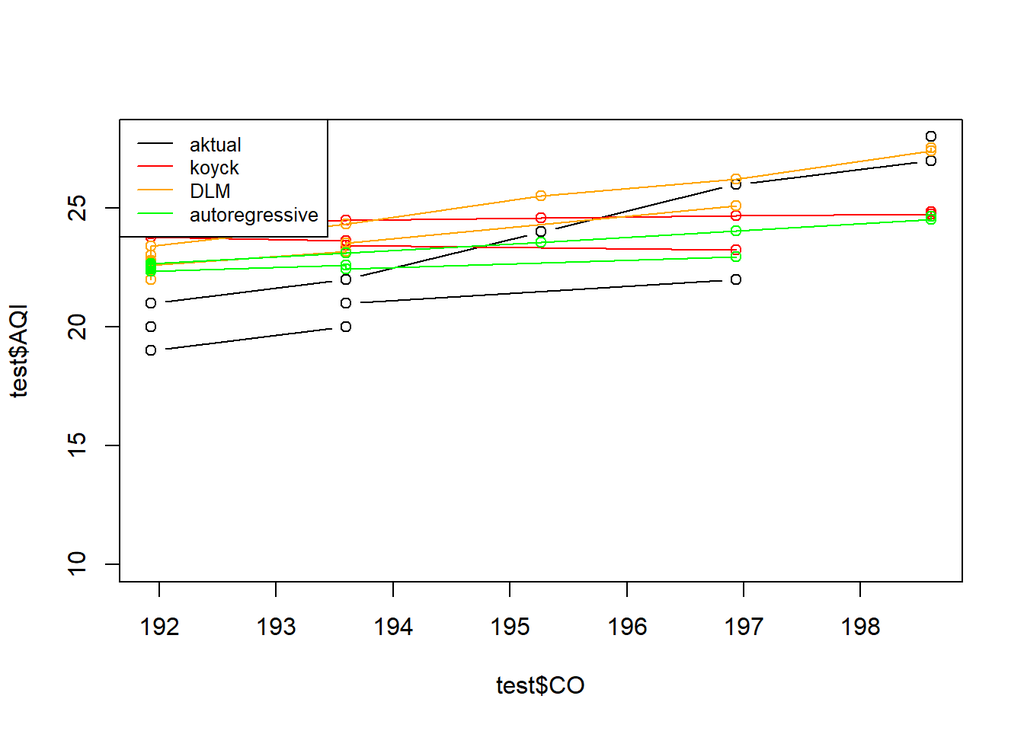

```r
par(mfrow=c(1,1))
plot(test$CO, test$AQI, type="b", col="black", ylim=c(10,28))
points(test$CO, fore.koyck$forecasts,col="red")
lines(test$CO, fore.koyck$forecasts,col="red")
points(test$CO, fore.dlm$forecasts,col="orange")
lines(test$CO, fore.dlm$forecasts,col="orange")
points(test$CO, fore.ardl$forecasts,col="green")
lines(test$CO, fore.ardl$forecasts,col="green")
legend("topleft",c("aktual", "koyck","DLM", "autoregressive"), lty=1, col=c("black","red","orange","green"), cex=0.8)
```